# Chapter C4

丸型、流線型、楕円型および角型管の引張、圧縮、曲げ、ねじりおよび組合せ荷重における強度と設計

## C4.1 はじめに

航空機用に応力外皮構造が登場する前、あるいは胴体や主翼が布張りであった時代には、胴体や主翼の主要構造の設計に丸型、楕円型、角型の管（チューブ）が使用されていた。主翼や尾翼が外部支柱で補強されている場合は、流線型の管が使用された。金属外皮構造の発達により、胴体や主翼の設計における管の使用はなくなったが、脚構造、エンジンマウント、操縦系統、客席などの固定装備品には管が引き続き使用された。

宇宙時代の到来とともに、宇宙空間では抗力が重要な要因ではないため、宇宙機の構造単位としての管が再び広く使用されるようになっている。丸管はねじり力を伝達するのに最適な形状であるため、操縦系統で広く使用されている。丸管および角管は、接続部や端部フィッティングの設計を単純にすることができる。金属業界からは、非常に多くの直径と肉厚のものが提供されており、構造設計者は多くのサイズから選択することができる。

## C4.2 引張設計

一般に、強度設計上の要求は、材料の引張降伏応力（ $F_{ty}$ ）を超えることなく制限荷重（Limit loads）を支持すること、および、制限荷重に安全率を乗じた値に等しい終局設計荷重（Ultimate design load）を破壊することなく支持することである。これは、引張応力が材料の終局引張強度（ $F_{tu}$ ）を超えてはならないことを意味する。一般に、航空機の安全率は $1.5$ である。無人ミサイルや宇宙機の場合、安全率は $1.2$ まで低くなることがある。材料の $F_{tu}$ と $F_{ty}$ の比は大きく異なるため、制限荷重下での降伏が終局設計荷重下での破壊よりも厳しくなることがあり、学生は常にどちらが致命的な状況であるかを確認する必要がある。

高温および暴露時間は材料の降伏強度および終局強度に影響を与えるため、軽量化に関する材料選定の問題は重要な設計要因となる。図 C4.1 は、材料の密度を $w$ としたときの、 $800$ 度までの高温に対する $F_{tu}/w$ 比のプロットを示している。管の材料は AISI 合金鋼および 2024 アルミニウム合金である。図 C4.1 を観察すると、温度が $350^{\circ}\text{F}$ 未満の場合、鋼が $F_{tu} = 180,000$ 以上に熱処理されていない限り、アルミニウム合金の方が軽い。 $350^{\circ}\text{F}$ を超えると、アルミニウム合金の終局強度は急速に低下するが、鋼は比較的均一な引張強度の低下を維持する。

このグラフは、時速約 $2000$ マイルで飛行する超音速機の表面全体にアルミニウム合金を使用できない理由を説明している。空力加熱によって、アルミニウム合金の強度が急速に低下する領域の表面温度が発生するためである。

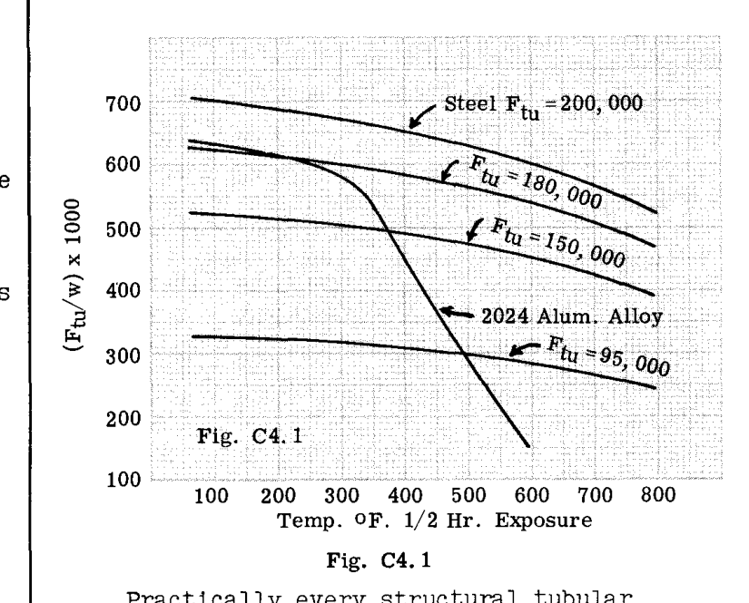

Fig. C4.1

飛行機の構造における実質的にすべての構造用管状部材は、隣接する他の部材に固定または取り付けられなければならない。接続は、リベット、ボルト、または溶接によって管に固定される端部フィッティングを使用して行うことができる。リベットやボルトを使用する場合、管壁に穴が開けられるため、管の断面積が削られて弱くなる。したがって、管の引張強度を計算する際には、任意の管横断面の有効断面積（ネットエリア）を使用しなければならない。接続に溶接を使用する場合、溶接熱によって溶接部に隣接する管材料の結晶粒が成長し、管の強度が低下するため、終局引張強度を計算する際には溶接補正係数を使用しなければならない。引張設計については、この章で後述する。

## C4.3 圧縮設計

柱として機能する場合の安定した断面を持つ部材の強度は、曲げ破壊が弾性的である場合、すなわち $E$ が一定であれば、オイラーの式（式 C4.1）によって計算でき、非弾性曲げ破壊の場合は、オイラーの式の $E$ を接線係数 $E_t$ に置き換えたもの（式 C4.2）が試験結果と一致する。（柱の強度に関する理論については、第 A18 章および第 C2 章を参照されたい。）

$$F_c = \frac{\pi^2 E}{(L'/\rho)^2}
\qquad\text{--- (C4.1)}$$

$$F_c = \frac{\pi^2 E_t}{(L'/\rho)^2}
\qquad\text{--- (C4.2)}$$

$L'$ は有効長であり、 $L/\sqrt{c}$ に等しい。ここで $c$ は柱端部固定度係数である。

### 短柱と長柱

長年にわたり、非弾性的な柱の強度または破壊の問題や主題は、ほとんど完全に試験結果の考慮から扱われてきた。すなわち、材料の比例限度応力を超える応力で破壊が生じる領域における破壊応力曲線の形状を確立するために、十分な試験が行われた。その後、試験結果に適合するように数学的曲線が導出された。技術者は、非弾性曲げによって破壊した柱を「短柱（ショートカラム）」と呼び、したがって試験データに適合する式を「短柱式」と呼んだ。弾性曲げによって破壊した柱は「長柱（ロングカラム）」と呼ばれた。長柱の試験曲線はオイラーの柱の式（C4.1）に従うため、いわゆる長柱の範囲において許容破壊応力を確立するための試験は必要なかった。このようにして、長年にわたり、試験結果に基づく短柱式が、構造設計に使用するために公式の政府機関から提示されてきた。宇宙航空分野の公式出版物は、ミリタリーハンドブック MIL-HDBK（文献 1）である。

## C4.4 丸型鋼管の柱公式

文献 1 による、基本的な短柱式は以下の通りである。

$$F_c = F_{co} \left[ 1 - \frac{F_{co} (L'/\rho)^2}{4\pi^2 E} \right]
\qquad\text{--- (C4.3)}$$

$$F_c = F_{co} \left\{ 1 - 0.3027
\frac{[(L'/\rho)/\pi]}{\sqrt{E/F_{co}}}^{1.5} \right\}
\qquad\text{--- (C4.4)}$$

ここで $F_{co}$ は柱の降伏応力（一次破壊に対する柱応力の上限）である。これは、非常に短い長さでブロック圧縮によって破壊が生じる試験曲線の急激な上昇傾向を無視し、短柱曲線を長さゼロに対応する点まで延長することによって、試験結果から決定することができる。表 C4.1 は、 $F_{co}$ と $E$ の値を式 C4.3 および C4.4 に代入し、オイラーの式に $E$ を代入した結果得られる短柱および長柱の式を示している。「遷移 $L'/\rho$ 」と題された列は、破壊が非弾性破壊から弾性破壊に変化する $L'/\rho$ の値を表しており、言い換えれば、いわゆる長柱領域と短柱領域の境界点である。したがって、これらの式を使用する場合は、適切な式を選択するために $L'/\rho$ の値を知る必要がある。

## C4.5 アルミニウム合金管の柱公式

文献 1 による、アルミニウム合金の基本的な短柱式は以下の通りである。

$$F_c = F_{co} \left[ 1 - \frac{0.385 (L'/\rho)}{\pi \sqrt{E/F_{co}}}
\right]
\qquad\text{--- (C4.5)}$$

$$F_c = F_{co} \left[ 1 - \frac{0.333 (L'/\rho)}{\pi \sqrt{E/F_{co}}}
\right]
\qquad\text{--- (C4.6)}$$

$$F_c = F_{co} \left[ 1 - \frac{0.272 (L'/\rho)}{\pi \sqrt{E/F_{co}}}
\right]
\qquad\text{--- (C4.7)}$$

長柱用：

$$F_c = \frac{\pi^2 E}{(L'/\rho)^2}
\qquad\text{--- (C4.8)}$$

$F_{co}$ を決定するための式は、表 C4.2（文献 1 より）に示されている。この表はまた、さまざまなアルミニウム合金材料に対して、3つの短柱式のうちどれを使用すべきかを示している。

表 C4.2 の使用方法を説明するために、2024-T3 アルミニウム合金管の柱公式を以下に導出する。

表 C4.2 から、 $F_{co}$ の式は以下の通りである。

$$F_{co} = F_{cy} (1 + \sqrt{F_{cy}/1000})$$

代入すると、

$$F_{co} = 42000 (1 + \sqrt{42/1000}) = 42000 (1 + .205) = 50600$$

表 C4.2 から、短柱式 C4.5 が適用されることがわかる。

この式に代入すると、

$$F_c = 50600 \left[ 1 - \frac{0.385 (L'/\rho)}{\pi
\sqrt{10,500,000/50600}} \right]$$

または

$$F_c = 50600 - 431 L'/\rho
\qquad\text{--- (C4.9)}$$

## C4.6 マグネシウム合金の柱公式

文献 1 による、さまざまなマグネシウム合金材料の短柱式は以下の通りである。

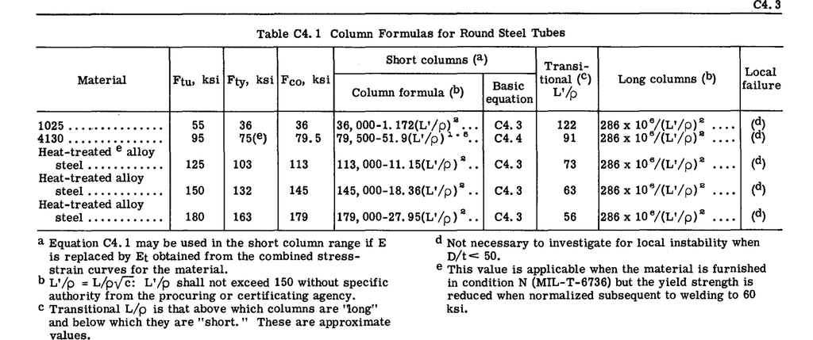

Table C4.1

これらは表 C4.4 および C4.4a に示されている。

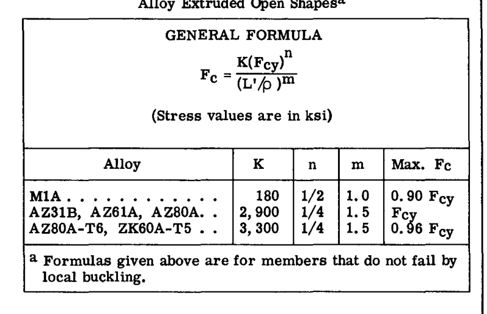

Table C4.4

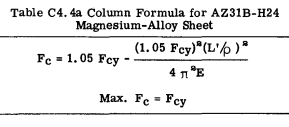

Table C4.4a

## C4.7 その他の材料の短柱式

短柱式が利用できない他の金属については、接線係数 $E_t$ を使用したオイラーの式（式 C4.2）を使用することができる。この式を使用した柱強度曲線の作成方法については、第 C2 章を参照されたい。

## C4.8 局所破損による柱の破壊

提示された式は、柱全体の曲げによる破壊に起因する許容応力を与えるものであり、その挙動は弾性的または非弾性的な柱全体の不安定性である。細長比 $L'/\rho$ が小さくなるにつれて、柱応力 $F_c$ は増加する。ここで、管の直径が比較的大きく肉厚が比較的薄い場合、すなわち直径対肉厚（ $D/t$ ）比が大きい場合、管壁の局所的な座屈または圧潰によって破壊が生じ、この局所的な破壊応力は通常、記号 $F_{cc}$ で表される。 $F_{cc}$ の値は一般に試験によって決定されている（ $D/t$ 比に対する $F_{cc}$ の設計チャートを参照）。

## C4.9 設計柱チャート

設計において、柱強度チャートは、さまざまな柱の式に代入するのに比べて大幅な時間の節約になるため、この章では柱の強度チェックおよび柱の強度設計を容易にするために、多くの柱チャートを提示している。図 C4.2 は、熱処理された丸型合金鋼管の $L'/\rho$ 対 $F_c$ のチャートである。図 C4.3 は、アルミニウム合金丸管の同様のタイプのチャートである。図 C4.4 は、マグネシウム合金材料の柱チャートである。3つのチャートはすべて文献 1 から引用したものである。図 C4.5 および C4.6 は、鉄鋼およびアルミニウムの丸管設計をさらに簡素化したものである。

## C4.10 丸管の断面特性

表 C4.3 は、丸管の断面特性を示している。管は、外径（ $D$ ）と肉厚（ $t$ ）を指定することによって指定される。したがって、「2-1/4 - .058」は、外径が $2-1/4$ インチ、肉厚が $.058$ インチの管を意味する。管は任意の軸に対して対称であるため、ねじり問題で必要となる極慣性モーメントは、表 C4.3 に示されている直交慣性モーメントの2倍に等しくなる。重量比較のために、鋼管およびアルミニウム管の重量が示されている。

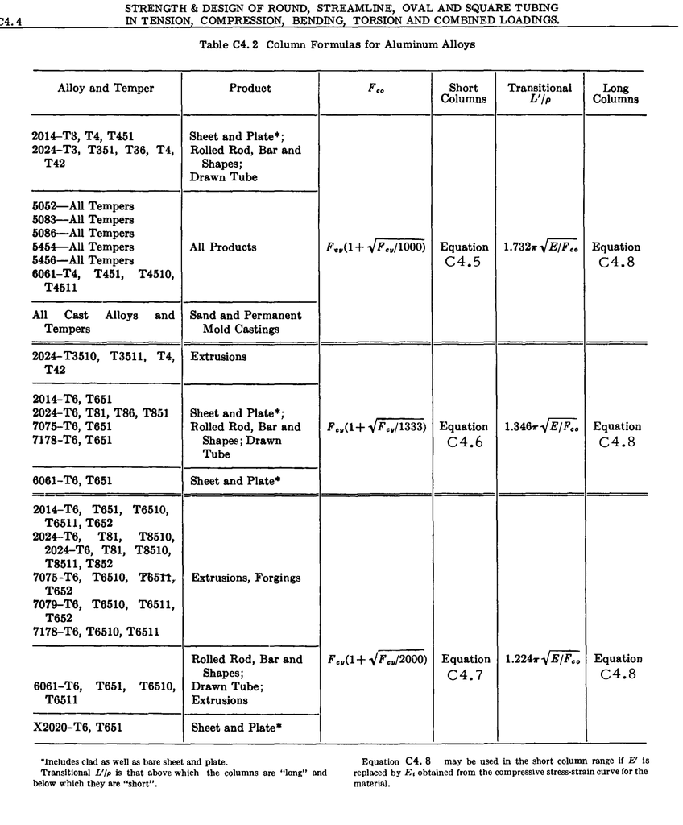

Table C4.2

## C4.11 管設計におけるいくつかの一般的な事実

1. 与えられた断面積に対して、局所的な座屈による破損が臨界的でない場合、管径が大きいほど柱強度は大きくなる。
2. 管の $D/t$ 比が高いほど、座屈または局所破損強度は低くなる。
3. 柱が長柱の範疇に入る場合、高強度の合金鋼やアルミニウム合金を使用しても柱の強度は増加しない。なぜなら、 $E$ はすべてのクロムモリブデン鋼合金において実質的に一定であり、すべてのアルミニウム合金においても同様だからである。破壊は柱全体の弾性座屈によるものであり、したがって $I$ 、 $L'$ および $E$ のみの関数となる。
4. 柱の端部拘束は、必要な管のサイズに影響を与える。この件に関しては、陸海軍および C.A.A. の設計要件を参照されたい。一般に、溶接されたスチール管トラスでは、エンジンマウントおよびナセル構造を除いて、 $C = 2$ の係数が許容される。リベット接合のトラスの場合、通常 $1.5$ 以下の値が許容される。
5. 学生は、強度と重量の考慮ではなく、クリアランスの要求などの実用的な制限によって管の直径が決定される場合があることを認識すべきである。したがって、設計は、与えられた制限下で利用可能な管をチェックすることで構成される場合がある。

## C4.12 鋼管の溶接が引張および柱強度に及ぼす影響

溶接は溶接部に隣接する管材料の結晶粒構造に影響を与えるため、試験によると、溶接部に隣接する材料の強度は溶接されていない材料と比較して低下することが示されている。テーパー溶接を使用すると、溶接の影響は軽減される。表 C4.5 は、引張荷重が作用する場合に使用する許容引張応力を示している。

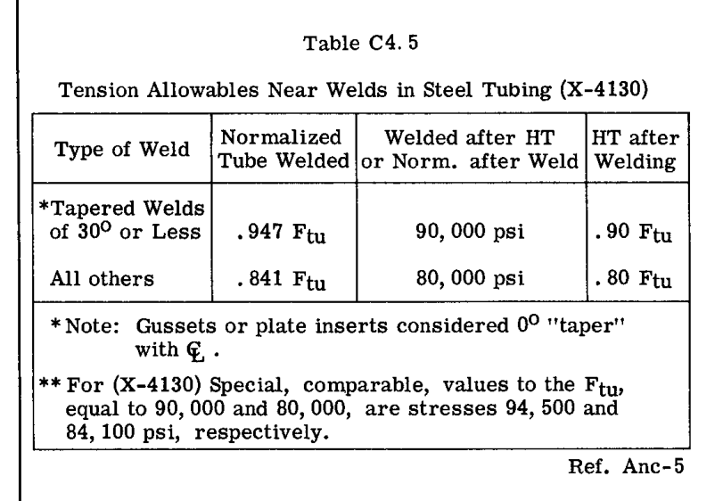

Table C4.5

短柱では、一次柱破壊応力が、管端部の溶接部に隣接する管の局所座屈強度よりも大きくなることがある。溶接によるこの局所破損応力は溶接カットオフ応力と呼ばれ、柱圧縮応力 $F_c$ はこの値を超えてはならない。このカットオフ溶接応力は、図 C4.2 および C4.5 の水平線で示されている。

## C4.13 柱および引張部材としての丸型鋼管の強度チェックおよび設計における例題

### 問題 1

管サイズ = 1-1/2 - .058、長さ $L = 30$ インチ。 端部固定度係数 $C = 1$ 。 材料：合金鋼、 $F_{tu} = 95000$ 。管は端部で溶接されている。 終局設計荷重：圧縮 $P = -14,500$ lbs.、引張 $P = 18500$ lbs.。 安全余裕（M.S.）を求めよ。

**解答**：圧縮の（M.S.）を最初に決定する。最も簡単な解決策として、図 C4.5 の柱曲線を使用することができる。長さ $30$ 、 $C = 1$ に対して、右上図から $1-1/2$ 径管との交点まで上方に投影し、次に左側の目盛りまで水平に投影して、柱強度 $14800$ lbs.（許容破壊荷重 $P_a$ ）を読み取る。

$$M.S. = \frac{P_a}{P} - 1 = \frac{14800}{14500} - 1 = .02$$

管の強度は、以下のように図 C4.2 を使用して求めることもできる。

$$L' = L/\sqrt{c} = 30/\sqrt{1} = 30$$

$$L'/\rho = 30/.5102 = 58.7$$

$\rho$ は表 C4.3 から求められ、管の断面積は $0.2628$ sq. in. である。下部目盛りの $L'/\rho$ に $58.7$ を使用し、下側の曲線である $F_{tu} = 95000$ 曲線まで上方に投影し、次に左側の目盛りまで水平に投影すると、 $F_c = 56500$ psi が読み取れる。

したがって、

$$P_a = F_c A = 56500 \times .2628 = 14850\text{ lb.}$$

この解決策は、明らかに $F_{tu} = 95000$ を持つ鋼の短柱式に代入することによって得られる。

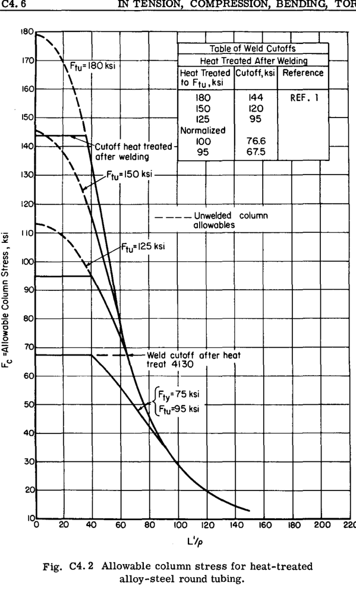

Fig. C4.2

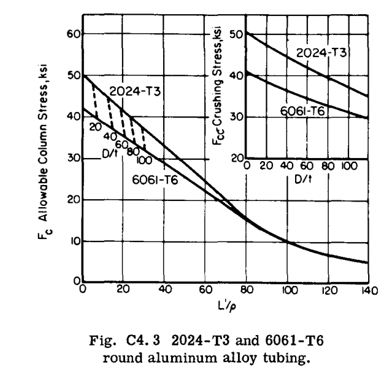

Fig. C4.3

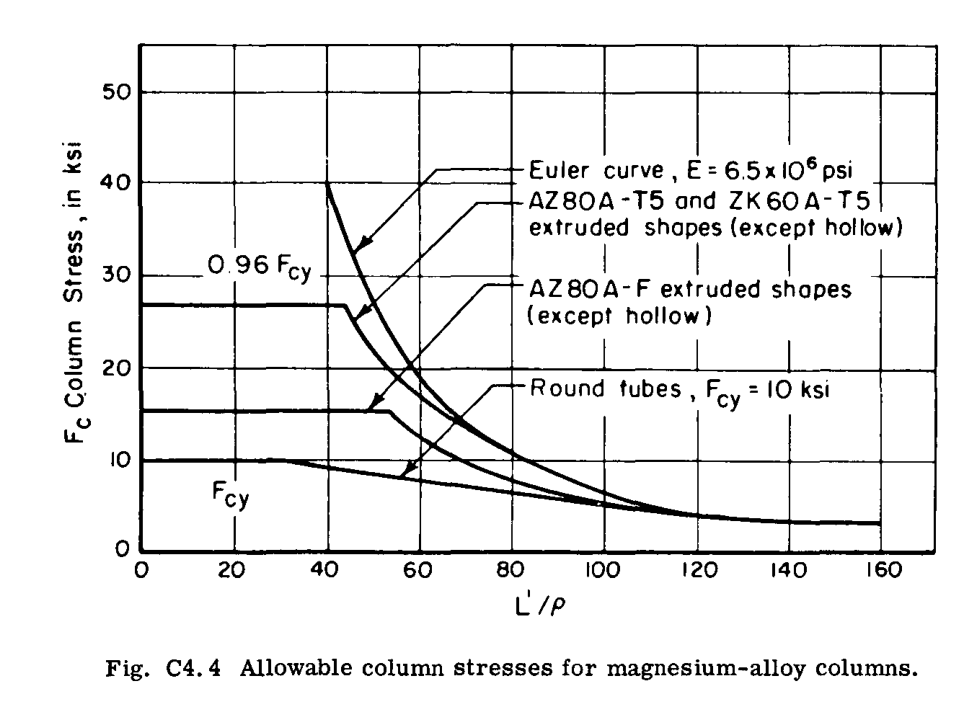

Fig. C4.4

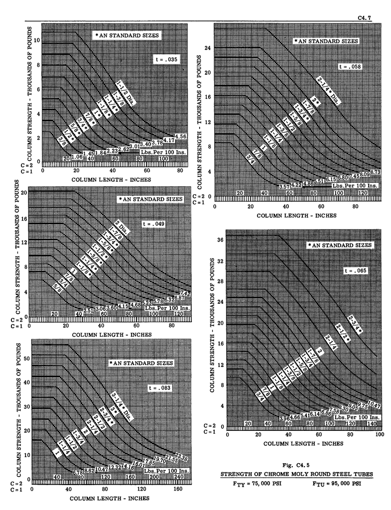

Fig. C4.5

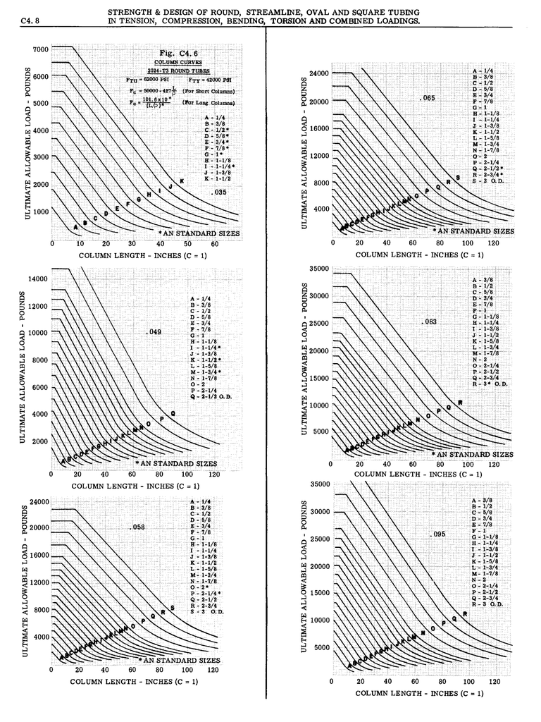

Fig. C4.6

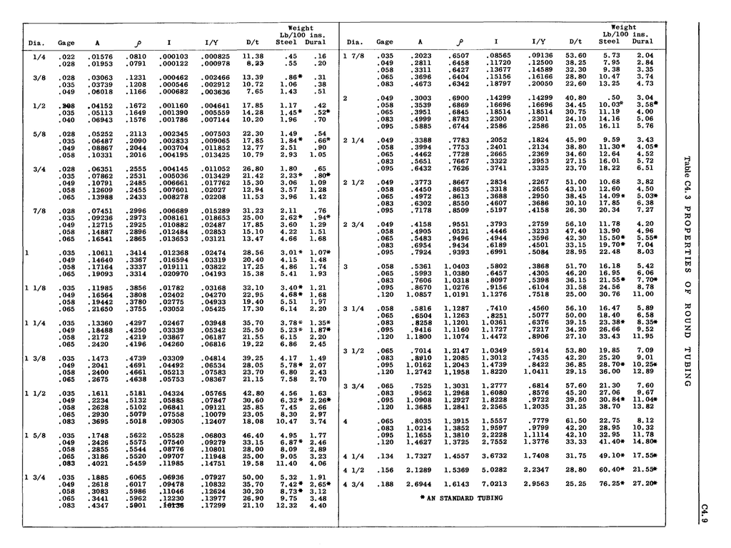

Table C4.3

$$F_c = 79500 - 51.9 (L'/\rho)^{1.5}$$

$$= 79500 - 51.9 (58.7)^{1.5} = 56500\text{ psi}$$

表 C4.1 に示されているように、遷移 $L'/\rho$ は $91$ であり、今回の管の値は $58.7$ であるため、短柱式が適用される。

#### 引張強度

管は溶接されているため、溶接部に隣接する管材料は弱くなっている。溶接補正値は表 C4.5 に示されている。テーパー溶接以外の溶接を想定する。 $P_a$ = 管の許容または破損引張強度とする。

$$P_a = F_{tu} \times (\text{溶接係数}) \times (\text{管の断面積})$$

$$= 95000 \times .841 \times .2628 = 21000\text{ lbs.}$$

$$M.S. = (P_a/P) - 1 = (21000/18500) - 1 = 0.13$$

したがって、圧縮の方が臨界的である。

### 問題 2

**ケース 1**：管サイズ 1-1/4 - .049、 $L = 40$ in.、 $c = 1$ 、材料：合金鋼、 $F_{tu} = 95000$ 。これが支持できる終局圧縮荷重を求めよ。

**解答**：図 C4.5 より、 $P_a = 6000$ lbs.。

**ケース 2**：管が $F_{tu} = 150,000$ に熱処理されていた場合、どのような圧縮荷重を支持できるか。

**解答**： $F_{tu} = 150,000$ であるため図 C4.5 は使用できない。したがって、図 C4.2 を使用する。 $L' = L/\sqrt{c} = 40/\sqrt{1} = 40$ 。表 C4.3 より、 $\rho = .425$ 、面積 ( $A$ ) = $.1849$ 。

$L'/\rho = 40/.425 = 94$ 。図 C4.2 から $150,000$ 曲線を使用すると、 $F_c = 32500$ が得られる。 したがって、 $P_a = F_c A = 32500 \times .1849 = 6000$ lb.。このように、管を $95000$ から $150,000$ に熱処理しても、柱の強度は増加しなかった。 $L'/\rho = 94$ の場合、それは長柱であり、破壊は弾性的であり $E$ は一定であるためである。

強度は、表 C4.1 のオイラーの式から計算することもできる。

$$F_c = 286,000,000 / (L'/\rho)^2$$

$$= 286,000,000 / (94)^2 = 32500\text{ psi}$$

これは以前に計算されたものと同じである。

**ケース 3**：ケース 1 と同じだが、管がその端部で他のいくつかの管に溶接されており、発達した端部固定度が $c = 2$ であると仮定する。

$$L' = L/\sqrt{c} = 40/\sqrt{2} = 28.4$$

図 C4.5 では、チャート下部の $L = 40$ および $c = 2$ の目盛りを使用するか、または $c = 1$ の目盛りと $L' = 28.4$ を使用することができる。チャートを読み取ると、 $P_a = 9200$ lbs. が得られる。このように、 $c = 2$ の固定度により、管の強度は $6000$ から $9200$ に増加した。

**ケース 4**：ケース 3 と同じだが、溶接後に $F_{tu} = 150,000$ に熱処理された場合。

$$L'/\rho = 28.4/.425 = 66.8$$

図 C4.2 から $150,000$ 曲線を使用して、 $F_c = 63000$ を読み取る。したがって、

$$P_a = F_c A = 63000 \times .1849 = 11650\text{ lb.}$$

このケースでは、熱処理によって追加の強度が発生したが、ケース 2 では発生しなかった。この理由は、破壊が非弾性応力範囲で発生し、熱処理によって非弾性範囲の材料特性が向上するためである。端部固定度により、柱はいわゆる長柱から短柱へと変化した。

強度は、表 C4.1 に示されている $150,000$ 鋼に等しい短柱式に代入することによっても求めることができる。

$$F_c = 145000 - 18.36 (L'/\rho)^2$$

$$= 145000 - 18.36 (66.8)^2 = 63000\text{ psi}$$

### 問題 3

**ケース 1**：管サイズ 2 - .065、 $L = 24$ 、 $c = 1.5$ 、材料 $F_{tu} = 95000$ 。端部で溶接。終局設計荷重 = $25000$ lbs.。M.S. はいくつか。

**解答**：

$$L' = L/\sqrt{c} = 24/\sqrt{1.5} = 19.7$$

$c = 1$ 目盛りの $L = 19.7$ に対する図 C4.5 から、2 インチ管まで上方に投影すると、それが水平な溶接カットオフ線と交差していることがわかり、左側の目盛りから許容柱荷重 $P_a = 26700$ lb. が得られる。この場合の破壊は、管端部の溶接部に隣接する局所的な座屈である。

$$M.S. = P_a/P = 26700/25000 - 1 = .07$$

**ケース 2**：管が溶接後に $F_{tu} = 125000$ に熱処理されたと仮定する。管の強度はいくつか。

$$L'/\rho = 19.7/.6845 = 28.8$$

図 C4.2 を使用して $L'/\rho = 28.8$ で $125000$ 曲線まで投影すると、再び水平な溶接カットオフ線と交差していることがわかる。

$$F_c = 95000\text{、したがって } P_a = 95000 \times .3951 = 37500\text{
lbs.}$$

管が端部で溶接されていなかった場合、柱曲線の破線部分を使用することができ、それによって追加の強度が得られたはずである。

### 問題 4

図 C4.7 は、1050 H.P. ラジアルエンジン用の鋼管製エンジンマウント構造を示している。応力解析から決定された、さまざまな飛行および着陸状態における各部材の終局設計引張および圧縮荷重が、各部材に隣接して括弧（ ）内に示されている。各部材の真の長さ $L$ も示されている。クロムモリブデン鋼管（ $F_{tu} = 95000$ ）を使用して、与えられた荷重に対して管のサイズを選定せよ。エンジンマウントはかなりの振動にさらされ、エンジンマウントリングによって与えられる真の剛性を正確に決定することは困難であるため、エンジンマウント部材に対して柱端部固定度 $c = 1$ を仮定するのが一般的な方法である。

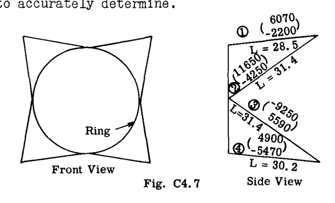

Fig. C4.7

部材 (3) を考慮する。終局設計荷重 = $-9250$ 。図 C4.5 の柱チャートを参照すると、 $C = 1$ および $L = 31.4$ に対して、 $-9250$ lbs. 付近の強度を持つ以下の管サイズが見つかる。

$$1-1/2 - .035,\quad P_a = 8850\text{ (弱い)。 (注 - } P_a =
\text{許容荷重)。}$$

$$1-3/8 - .049,\quad P_a = -10350,\quad \text{重量} = 5.78\text{
lb./100", } M.S. = (10350/9250) - 1 = .12$$

$$1-1/4 - .058,\quad P_a = -10000,\quad \text{重量} = 6.15,\quad M.S. =
(10000/9250) - 1 = .08$$

したがって、最も軽くて最も強い $1-3/8 - .049$ を使用する。

部材 (4) を考慮する。荷重 = $-5470$ 、 $L = 30$ 、 $c = 1$

図 C4.5 より：

$$1-1/8 - .049,\quad P_a = -7100,\quad \text{wt.} = 4.68,\quad M.S. = .30$$

$$1-1/4 - .035,\quad P_a = -6500,\quad \text{wt.} = 3.78,\quad M.S. = .19$$

$$1" - .058,\quad P_a = -6000,\quad \text{wt.} = 4.86,\quad M.S. =
.10$$

結果は、 $1-1/4 - .035$ が最も軽いことを示している。 $.035$ の厚さを他の重い管ゲージ、特にこのサイズのエンジンに対して通常比較的重いエンジンマウントリングに溶接することには危険があるため、最小管肉厚は $.049$ が使用され、したがって $1-1/8 - .049$ の管が選択される。

部材 (2) を考慮する

設計荷重は引張 $11650$ および圧縮 $4250$ である。引張荷重の方が厳しいと思われるため、管は引張荷重に対して設計され、その後圧縮荷重に対してチェックされる。材料の $F_{tu}$ は $95000$ psi である。溶接構造のエンジンマウントでは、端部溶接部に隣接する管の強度を $0.841 \times 95000 = 80000$ psi に低下させなければならない（表 C4.5 を参照）。

したがって、必要な管断面積 = $11650 / 80000 = 0.146$ sq. in. である。丸管の断面特性を示す表 C4.3 から、以下のサイズを選択する。

$$1 - .049,\quad \text{面積} = .146,\quad M.S. = (.146/.146) - 1 = 0$$

$$1-1/8 - .049,\quad \text{面積} = .166,\quad M.S. = .14$$

$$1-3/8 - .035,\quad \text{面積} = .147,\quad M.S. = 0$$

合理的な安全余裕を得るために、 $1-1/8 - .049$ が選択される。

多くの構造設計者は、エンジンマウント部材の破損やひび割れに関してかなりのトラブルに遭遇しているため、エンジンマウント部材に大きな安全余裕を持たせることを好む。

長さ $31.4$ および $c = 1$ に対する柱としての $1-1/8 - .049$ 管の強度は、図 C4.5 から $-6700$ lbs. に等しく、これは最大圧縮荷重に対して $(6700/4250) - 1 = .58$ の安全余裕を与える。学生は部材 (1) の管サイズを選択すべきである。

## C4.14 アルミニウム合金およびマグネシウム丸管を柱および引張部材として使用した例題

一般に、合金鋼の丸管は、材料重量ベースでアルミニウムの丸管と有利に比較できるようになる前に、終局引張強度が約 $180,000$ から $200,000$ になるまで熱処理されなければならない。しかし、管に使用されるアルミニウム合金は十分に溶接することができないため、トラス構造において、リベット接合やボルト接合を伴う端部接続は、鋼トラスにおける溶接接続と比較して、重量を増加させ、設計を困難にする。